# Tarea 04 - Modelos de Factores y DIC

Arantza Ivonne Pineda Sandoval

En este trabajo se desarrollan los scripts para 4 modelos de factores y los DIC correspondientes. La base de datos utilizada es de los tipos de cambio (USD). Finalmente se realiza una comparación de los DIC.

## Cargar Librerías y Leer Datos

```r
library("MCMCpack")
library("lubridate")
library("bayesdfa")
library("Rcpp")
library("factorstochvol")
library("gtools")
library("mvtnorm")
library("readxl")
library("tidyverse")
library("gridExtra")
data <- read.csv("est46114_s06_data.csv")

data_3paises <- data%>%select("Canada", "Mexico", "Zambia")
head(data_3paises)
```

```
##     Canada   Mexico   Zambia
## 1 1.106447 9.375124 4756.588
## 2 1.107866 9.424495 4733.821
## 3 1.112132 9.446914 4711.274
## 4 1.111930 9.495182 4692.517
## 5 1.116786 9.509138 4665.879
## 6 1.084892 9.508372 4643.275
```

Para tener una visualización de los datos originales considerando los 3 países bajo interés: Canadá, México y Zambia se grafican las series de tiempo:

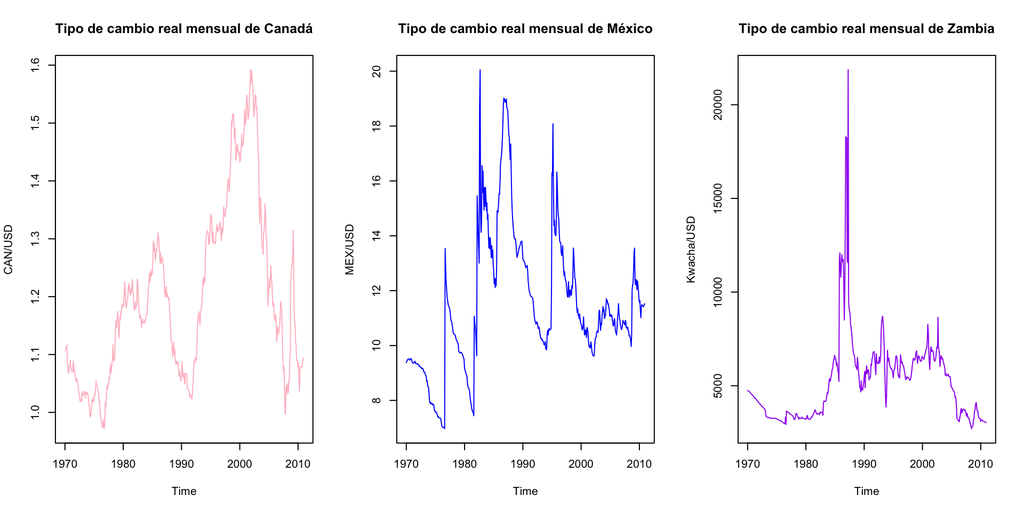

```r
tipo_de_cambio_canada <- ts(data$Canada,start = c(1970,01), frequency = 12)
tipo_de_cambio_zambia <- ts(data$Zambia,start = c(1970,01), frequency = 12)
tipo_de_cambio_mexico <- ts(data$Mexico,start = c(1970,01), frequency = 12)
par(mfrow = c(1,3))
plot(tipo_de_cambio_canada, main = "Tipo de cambio real mensual de Canadá", col = "pink", ylab="CAN/USD")
plot(tipo_de_cambio_mexico, main = "Tipo de cambio real mensual de México", col = "blue", ylab="MEX/USD")
plot(tipo_de_cambio_zambia, main = "Tipo de cambio real mensual de Zambia", col = "purple", ylab="Kwacha/USD")
```

## 1) Modelo de factores k=1

Se genera un primer modelo de factores k=1 usando la función MCMfactanal y sin restricciones:

```r
n_sim <- 1000
n_burnin <- 100

fa.posterior_1 <- MCMCfactanal(~Canada+Mexico+Zambia,
                             factors=1,
                             verbose=0, store.scores=FALSE,
                             a0=1, b0=0.15,
                             data=data_3paises,
                             burnin=n_burnin, mcmc=n_sim, thin=1)

resumen_modelo_1 <-summary(fa.posterior_1)
resumen_modelo_1
```

```
##
## Iterations = 101:1100
## Thinning interval = 1
## Number of chains = 1
## Sample size per chain = 1000
##
## 1. Empirical mean and standard deviation for each variable,
##    plus standard error of the mean:
##
##                   Mean      SD Naive SE Time-series SE
## LambdaCanada_1 0.45048 0.04468 0.001413       0.002400
## LambdaMexico_1 0.59144 0.04310 0.001363       0.005344
## LambdaZambia_1 0.97007 0.03601 0.001139       0.007828
## PsiCanada      0.79813 0.05078 0.001606       0.001606
## PsiMexico      0.64507 0.04536 0.001434       0.003675
## PsiZambia      0.04771 0.04201 0.001329       0.015552
##
## 2. Quantiles for each variable:
##
##                   2.5%     25%     50%     75%  97.5%
## LambdaCanada_1 0.36338 0.42006 0.45035 0.48120 0.5371
## LambdaMexico_1 0.51369 0.56113 0.58963 0.61951 0.6819
## LambdaZambia_1 0.89818 0.94902 0.96855 0.99154 1.0466
## PsiCanada      0.70317 0.76338 0.79451 0.83144 0.8983
## PsiMexico      0.56119 0.61579 0.64354 0.67619 0.7320
## PsiZambia      0.01348 0.02088 0.03028 0.06499 0.1635
```

Se extraen los datos necesarios de los resultados anteriores para con ellos poder calcular el DIC:

```r
# Función para extraer modas y usarlas en extraccion de lambdas y sigmas
calculoModa <- function(v) {
uniqv <- unique(v)
uniqv[which.max(tabulate(match(v, uniqv)))]
}

#Extraer número de parámetros
num_parametros1<-nrow(resumen_modelo_1$statistics)
print("*Numero de Parametros*")
```

```
## [1] "*Numero de Parametros*"
```

```r
num_parametros1
```

```
## [1] 6
```

```r
# Extraer vector de lambdas
modelo_1_lambdas<-apply(fa.posterior_1[,grep("Lambda",colnames(fa.posterior_1))],2,calculoModa)
print("*Lambdas*")
```

```
## [1] "*Lambdas*"
```

```r
modelo_1_lambdas
```

```
## LambdaCanada_1 LambdaMexico_1 LambdaZambia_1
##      0.4820291      0.5829299      0.9774148
```

```r
# Extraer vector de sigmas
modelo_1_sigmas<-diag(apply(fa.posterior_1[,grep("Psi",colnames(fa.posterior_1))],2,calculoModa))
print("*Sigmas*")
```

```
## [1] "*Sigmas*"
```

```r
modelo_1_sigmas
```

```
##           [,1]      [,2]       [,3]
## [1,] 0.7633984 0.0000000 0.00000000
## [2,] 0.0000000 0.6560048 0.00000000
## [3,] 0.0000000 0.0000000 0.04341383
```

Para calcular la medida DIC que ayuda a la comparación de modelos se genera la siguiente función:

```r
calcula_DIC<-function(data,mu=NULL,Lambda,Sigma,parametros){

  if(is.null(mu)){
     mu=matrix(0,ncol=ncol(Sigma),nrow = 1)
  }

  matriz_omega<-as.matrix(Lambda)%*% t(as.matrix(Lambda))+as.matrix(Sigma)

  # Verosimilitud con función dmvnorm
  norm.dense<-apply(data,1,function(x) mvtnorm::dmvnorm(x,mean=mu,sigma=matriz_omega,log=TRUE))
  log.like<-sum(norm.dense)

  DIC=-2*log.like+2*parametros     #Se utiliza la fórmula del DIC para calcular
  return(DIC)

}
```

Se calcula el DIC para el modelo de k=1:

```r
DIC_completo1<-calcula_DIC(data=data_3paises,mu=NULL,Lambda=modelo_1_lambdas,Sigma=modelo_1_sigmas,parametros=num_parametros1)
DIC_completo1
```

```
## [1] 27715678908
```

## 2) Modelo de factores k=2

Se genera el modelo para dos factores k=2:

```r
n_sim <- 1000
n_burnin <- 100

fa.posterior_2 <- MCMCfactanal(~Canada+Mexico+Zambia,
                             factors=2,
                            #lambda.constraints=list(Canada=c(1,0), Mexico=c(0,1)),
                             verbose=0, store.scores=FALSE,
                             a0=1, b0=0.15,
                             data=data_3paises,
                             burnin=n_burnin, mcmc=n_sim, thin=1)

resumen_modelo_2 <-summary(fa.posterior_2)
resumen_modelo_2
```

```
##
## Iterations = 101:1100
## Thinning interval = 1
## Number of chains = 1
## Sample size per chain = 1000
##
## 1. Empirical mean and standard deviation for each variable,
##    plus standard error of the mean:
##
##                   Mean      SD Naive SE Time-series SE
## LambdaCanada_1  0.1293 0.15010 0.004746        0.06307
## LambdaCanada_2  0.9038 0.10915 0.003452        0.04380
## LambdaMexico_1 -0.5487 0.08478 0.002681        0.02360
## LambdaMexico_2  0.3039 0.10684 0.003379        0.04284
## LambdaZambia_1 -0.7233 0.16272 0.005146        0.07425
## LambdaZambia_2  0.5936 0.11337 0.003585        0.04966
## PsiCanada       0.1451 0.13589 0.004297        0.07214
## PsiMexico       0.6017 0.06634 0.002098        0.02220
## PsiZambia       0.1059 0.08240 0.002606        0.04115
##
## 2. Quantiles for each variable:
##
##                    2.5%      25%      50%     75%   97.5%
## LambdaCanada_1 -0.04412  0.02895  0.07199  0.2194  0.5997
## LambdaCanada_2  0.63707  0.84885  0.94033  0.9750  1.0501
## LambdaMexico_1 -0.70351 -0.59681 -0.55249 -0.5122 -0.3131
## LambdaMexico_2  0.14550  0.23034  0.28728  0.3512  0.5989
## LambdaZambia_1 -0.88707 -0.83085 -0.75615 -0.6977 -0.2132
## LambdaZambia_2  0.42517  0.50417  0.56502  0.6718  0.8543
## PsiCanada       0.02153  0.04045  0.08319  0.2380  0.4917
## PsiMexico       0.44816  0.56805  0.61158  0.6468  0.7117
## PsiZambia       0.01269  0.04422  0.07828  0.1590  0.3039
```

Se extraen los datos necesarios de los resultados anteriores para con ellos poder calcular el DIC:

```r
#Extraer número de parámetros
num_parametros2<-nrow(resumen_modelo_2$statistics)
print("*Numero de Parametros*")
```

```
## [1] "*Numero de Parametros*"
```

```r
num_parametros2
```

```
## [1] 9
```

```r
#Extraer Lambdas
modelo_2_lambdas<-cbind(apply(fa.posterior_2[,grep(regex("^(Lambda).+(\\_1$)"),
                                                   colnames(fa.posterior_2))],2,calculoModa),
                        c(apply(fa.posterior_2[,grep(regex("^(Lambda).+(\\_2$)"),
                                                colnames(fa.posterior_2))],2,calculoModa)))
print("*Lambdas*")
```

```
## [1] "*Lambdas*"
```

```r
modelo_2_lambdas
```

```
##                      [,1]      [,2]
## LambdaCanada_1  0.5581237 0.6786722
## LambdaMexico_1 -0.3661213 0.6137470
## LambdaZambia_1 -0.2625946 0.7792864
```

```r
# Extraer vector de sigmas
modelo_2_sigmas<-diag(apply(fa.posterior_2[,grep("Psi",colnames(fa.posterior_2))],2,calculoModa))
print("*Sigmas*")
```

```
## [1] "*Sigmas*"
```

```r
modelo_2_sigmas
```

```
##           [,1]      [,2]      [,3]
## [1,] 0.2420786 0.0000000 0.0000000
## [2,] 0.0000000 0.4993247 0.0000000
## [3,] 0.0000000 0.0000000 0.2712919
```

Se calcula el DIC para el modelo de k=2:

```r
DIC_completo2<-calcula_DIC(data=data_3paises,mu=NULL,Lambda=modelo_2_lambdas,Sigma=modelo_2_sigmas,parametros=num_parametros2)
DIC_completo2
```

```
## [1] 28588662360
```

## 3) Modelo de factores estático (medias cambiantes)

Para poder generar este modelo, primero se estandarizan los datos con sus medias anuales y desviaciones estándar:

```r
data <- read_excel('est46114_s06_data.xls')

#2 Funciones de estandarización
tipo_de_cambio_pais_promedio_anual <- function(x = tipo_de_cambio,pais = "Canada"){
  fecha <- as.Date(x$Date)
  tipo_de_cambio_mensual <-unname(unlist(x[pais]))

  datos_mensuales <- data_frame(fecha, tipo_de_cambio_mensual)

  datos_anuales <- datos_mensuales %>%
    group_by(year=floor_date(fecha, "year")) %>%
    summarize(media_anual = mean(tipo_de_cambio_mensual),
              desv_anual = sd(tipo_de_cambio_mensual))
  datos_anuales

}


tipo_de_cambio_pais_estandarizado <- function(x, pais){
    datos_mensuales <- x %>% select(Date,pais) %>% mutate(ano = year(Date)) %>% rename(tipo_de_cambio = pais)
    datos_anuales <- tipo_de_cambio_pais_promedio_anual(x,pais) %>% mutate(ano = year(year))

    datos_estandarizados <- datos_mensuales %>% left_join(datos_anuales, by=c("ano")) %>% mutate(tc_estandarizado = (tipo_de_cambio-media_anual) / desv_anual)

    datos_estandarizados %>% select(Date,ano, tc_estandarizado)
}

#Estandarizar la base de datos completa

paises_de_interes <- names(data)[-1]

lista_paises_estandarizados <- lapply(paises_de_interes, tipo_de_cambio_pais_estandarizado, x = data)
names(lista_paises_estandarizados) <- names(data)[-1]

df_estandar <- bind_rows(lista_paises_estandarizados, .id = "column_label") %>%
  spread(column_label,tc_estandarizado)

df_estandar
```

```
## # A tibble: 492 x 82
##    Date                  ano Algeria Argentina Australia Austria Bangladesh
##    <dttm>              <dbl>   <dbl>     <dbl>     <dbl>   <dbl>      <dbl>
##  1 1970-01-01 00:00:00  1970   1.51     -0.432    -1.60  -2.32       1.18
##  2 1970-02-01 00:00:00  1970   1.24     -0.510    -1.44  -0.913      1.05
##  3 1970-03-01 00:00:00  1970   0.967    -0.693    -1.15   0.157      0.922
##  4 1970-04-01 00:00:00  1970   0.719    -0.694    -0.671  1.06       0.906
##  5 1970-05-01 00:00:00  1970   0.434    -0.785    -0.285  1.28       0.654
##  6 1970-06-01 00:00:00  1970   0.171     0.784     0.465 -0.0314     0.481
##  7 1970-07-01 00:00:00  1970  -0.129     1.58      1.02  -1.00       0.0629
##  8 1970-08-01 00:00:00  1970  -0.464     1.36      1.02  -0.179     -0.589
##  9 1970-09-01 00:00:00  1970  -0.717     0.979     1.12   0.354     -0.768
## 10 1970-10-01 00:00:00  1970  -0.970     0.280     0.891  0.458     -0.957
## # … with 482 more rows, and 75 more variables: Benin <dbl>, Brazil <dbl>,
## #   Cameroon <dbl>, Canada <dbl>, Chile <dbl>, `China,PR` <dbl>,
## #   Colombia <dbl>, Congo <dbl>, `Costa Rica` <dbl>, `Cote
## #   d'Ivoire` <dbl>, `Czech Rep` <dbl>, Denmark <dbl>, `Dominican
## #   Rep` <dbl>, Ecuador <dbl>, Egypt <dbl>, `El Salvador` <dbl>,
## #   EU12 <dbl>, Finland <dbl>, France <dbl>, Germany <dbl>, Ghana <dbl>,
## #   Greece <dbl>, Guatemala <dbl>, Honduras <dbl>, `Hong Kong` <dbl>,
## #   Hungary <dbl>, India <dbl>, Indonesia <dbl>, Ireland <dbl>,
## #   Israel <dbl>, Italy <dbl>, Jamaica <dbl>, Japan <dbl>, Jordan <dbl>,
## #   Kenya <dbl>, Korea <dbl>, Kuwait <dbl>, Luxembourg <dbl>,
## #   Malaysia <dbl>, Mexico <dbl>, Morocco <dbl>, Mozambique <dbl>,
## #   Netherlands <dbl>, `New Zealand` <dbl>, Nicaragua <dbl>,
## #   Nigeria <dbl>, Norway <dbl>, Pakistan <dbl>, Panama <dbl>,
## #   Paraguay <dbl>, Peru <dbl>, Philippines <dbl>, Poland <dbl>,
## #   Portugal <dbl>, Russia <dbl>, `Saudi Arabia` <dbl>, Senegal <dbl>,
## #   `Sierra Leone` <dbl>, Singapore <dbl>, `South Africa` <dbl>,
## #   Spain <dbl>, `Sri Lanka` <dbl>, Sweden <dbl>, Switzerland <dbl>,
## #   Syria <dbl>, Taiwan <dbl>, Tanzania <dbl>, Thailand <dbl>,
## #   `Trin/Tobago` <dbl>, Tunisia <dbl>, Turkey <dbl>, U.K. <dbl>,
## #   Uruguay <dbl>, Venezuela <dbl>, Zambia <dbl>
```

Para visualizar la estandarización se grafican los 3 países de interés:

```r
#Dataframe
data_3paises_estandar <- df_estandar%>%select("Canada", "Mexico", "Zambia")
head(data_3paises_estandar)
```

```
## # A tibble: 6 x 3
##   Canada Mexico Zambia
##    <dbl>  <dbl>  <dbl>
## 1  0.800 -2.33   1.44
## 2  0.880 -1.21   1.20
## 3  1.12  -0.704  0.961
## 4  1.11   0.390  0.762
## 5  1.39   0.706  0.480
## 6 -0.421  0.689  0.240
```

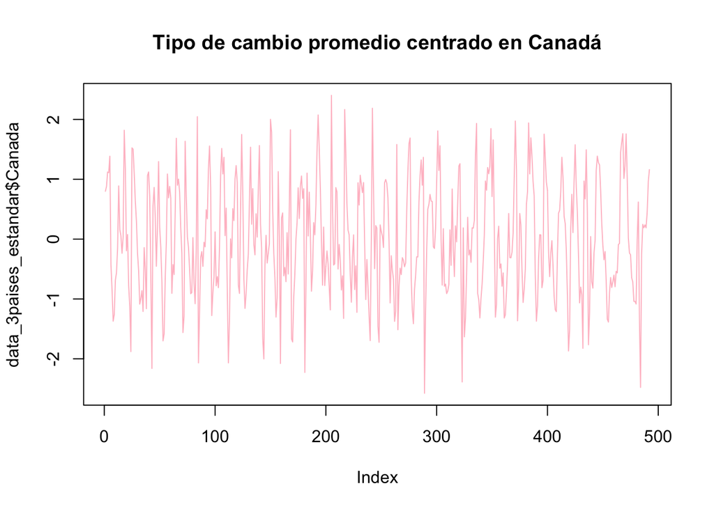

```r
#Gráficas
g1<-plot(data_3paises_estandar$Canada, main="Tipo de cambio promedio centrado en Canadá", type ="l", col= "pink")
```

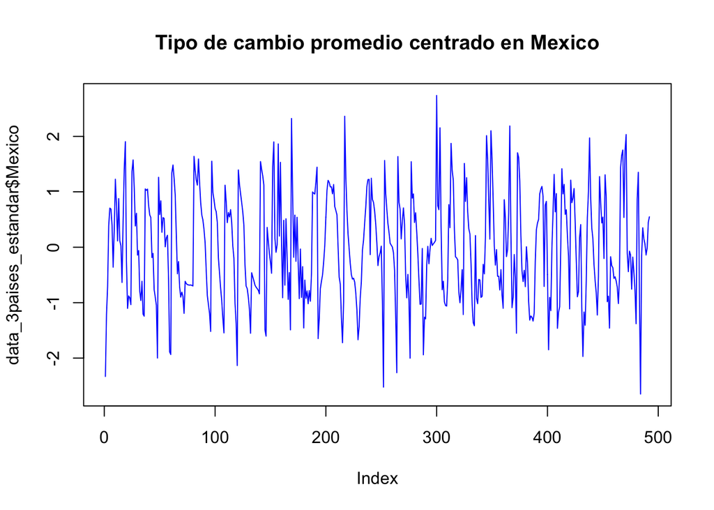

```r
g2<-plot(data_3paises_estandar$Mexico, main="Tipo de cambio promedio centrado en Mexico",  type = "l",col= "blue")
```

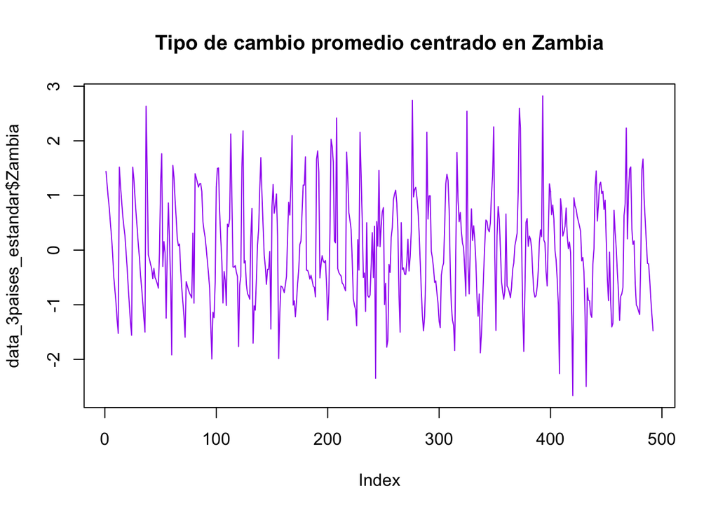

```r
g3<-plot(data_3paises_estandar$Zambia, main="Tipo de cambio promedio centrado en Zambia", type = "l", col= "purple")
```

Con estos datos ajustados a sus medias se genera el modelo estático con 1 factor:

```r
n_sim <- 1000
n_burnin <- 100

fa_Est_MediasCam.posterior_3 <- MCMCfactanal(~Canada+Mexico+Zambia,
                             factors=1,
                             verbose=0, store.scores=FALSE,
                             a0=1, b0=0.15,
                             data=data_3paises_estandar,
                             burnin=n_burnin, mcmc=n_sim, thin=1)

resumen_modelo_3 <-summary(fa_Est_MediasCam.posterior_3)
resumen_modelo_3
```

```
##
## Iterations = 101:1100
## Thinning interval = 1
## Number of chains = 1
## Sample size per chain = 1000
##
## 1. Empirical mean and standard deviation for each variable,
##    plus standard error of the mean:
##
##                   Mean      SD Naive SE Time-series SE
## LambdaCanada_1 -0.1705 0.05712 0.001806       0.003374
## LambdaMexico_1 -0.2418 0.07237 0.002288       0.019050
## LambdaZambia_1 -0.8793 0.14589 0.004613       0.105481
## PsiCanada       0.9757 0.06320 0.001999       0.002277
## PsiMexico       0.9395 0.06854 0.002168       0.008064
## PsiZambia       0.2205 0.22429 0.007093       0.169193
##
## 2. Quantiles for each variable:
##
##                    2.5%      25%     50%     75%    97.5%
## LambdaCanada_1 -0.28137 -0.20670 -0.1692 -0.1316 -0.06325
## LambdaMexico_1 -0.41463 -0.27777 -0.2326 -0.1923 -0.13243
## LambdaZambia_1 -1.02862 -0.99152 -0.9426 -0.7879 -0.52812
## PsiCanada       0.85677  0.93237  0.9698  1.0147  1.10556
## PsiMexico       0.80264  0.89374  0.9383  0.9875  1.06922
## PsiZambia       0.01594  0.02805  0.1373  0.3879  0.72659
```

Se extraen los datos necesarios para el cálculo del DIC:

```r
#Extraer número de parámetros
num_parametros3<-nrow(resumen_modelo_3$statistics)
print("*Numero de Parametros*")
```

```
## [1] "*Numero de Parametros*"
```

```r
num_parametros3
```

```
## [1] 6
```

```r
# Extraer vector de lambdas
modelo_3_lambdas<-apply(fa_Est_MediasCam.posterior_3 [,grep("Lambda",colnames(fa_Est_MediasCam.posterior_3 ))],2,calculoModa)
print("*Lambdas*")
```

```
## [1] "*Lambdas*"
```

```r
modelo_3_lambdas
```

```
## LambdaCanada_1 LambdaMexico_1 LambdaZambia_1
##     -0.1590250     -0.2384581     -0.7777162
```

```r
# Extraer vector de sigmas
modelo_3_sigmas<-diag(apply(fa_Est_MediasCam.posterior_3 [,grep("Psi",colnames(fa_Est_MediasCam.posterior_3 ))],2,calculoModa))
print("*Sigmas*")
```

```
## [1] "*Sigmas*"
```

```r
modelo_3_sigmas
```

```
##           [,1]      [,2]      [,3]
## [1,] 0.9336334 0.0000000 0.0000000
## [2,] 0.0000000 0.9775798 0.0000000
## [3,] 0.0000000 0.0000000 0.3167988
```

A continuación se calcula el DIC:

```r
DIC_completo3<-calcula_DIC(data=data_3paises_estandar,mu=NULL,Lambda=modelo_3_lambdas,Sigma=modelo_3_sigmas,parametros=num_parametros3)
DIC_completo3
```

```
## [1] 4044.863
```

## 4) Modelo dinámico (en medias)

```r
dfa.posterior_4 <- fit_dfa(y = t(data_3paises_estandar), iter = 1000, chains = 1)

ls(dfa.posterior_4)
summary(dfa.posterior_4)
```

[output not shown]

Para extraer los valores necesarios para el cálculo del DIC:

```r
#Verosimilitud
verosim_mod4<-sum(dfa.posterior_4$model@par_dims$log_lik)
verosim_mod4
```

```
## [1] 1476
```

```r
#Se obtienen los parámetros correspondientes a la suma de : Sigma, y las matrices W y G
num_parametros4<-dim(dfa.posterior_4$samples_permuted$Z)[2]+  dim(dfa.posterior_4$samples_permuted$sigma)[2]+  dim(dfa.posterior_4$samples_permuted$psi)[2]
num_parametros4
```

```
## [1] 5
```

Se calcula el DIC del modelo 4:

```r
#DIC
DIC_completo4<-2*verosim_mod4+2*num_parametros4
DIC_completo4
```

```
## [1] 2962
```

## Comparación de modelos

Una vez que se han analizados los 4 modelos, se genera una tabla comparativa de los resultados:

```r
tablaCompara<-data_frame(Modelo=c("1) Modelo de factores con k=1",
                                    "2) Modelo de factores con k=2",
                                    "3) Modelo de factores estático (medias cambiantes)",
                                    "4) Modelo Dinámico en Medias"),
                        DIC=c(DIC_completo1,DIC_completo2,DIC_completo3,DIC_completo4),
                        Número_de_Parámetros=c(num_parametros1,num_parametros2, num_parametros3, num_parametros4))

tablaCompara
```

```
## # A tibble: 4 x 3
##   Modelo                                            DIC Número_de_Parámetr…
##   <chr>                                           <dbl>               <int>
## 1 1) Modelo de factores con k=1                 2.77e10                   6
## 2 2) Modelo de factores con k=2                 2.86e10                   9
## 3 3) Modelo de factores estático (medias c…     4.04e 3                   6
## 4 4) Modelo Dinámico en Medias                  2.96e 3                   5
```

Acorde a la tabla, el mejor modelo es el modelo con el menor DIC, en este caso es el modelo 4) dinámico en medias.